# IODS course project

## Preparation of the data for LDA

Next, the data needs to be scaled for further analysis (because in linear discriminant analysis the variables need to have the same variance). After scaling, data has transformed as matrix, so let’s change it to data frame again.

```r
boston_scaled <- scale(Boston)
summary(boston_scaled)
```

```
##       crim                 zn               indus              chas
##  Min.   :-0.419367   Min.   :-0.48724   Min.   :-1.5563   Min.   :-0.2723
##  1st Qu.:-0.410563   1st Qu.:-0.48724   1st Qu.:-0.8668   1st Qu.:-0.2723
##  Median :-0.390280   Median :-0.48724   Median :-0.2109   Median :-0.2723
##  Mean   : 0.000000   Mean   : 0.00000   Mean   : 0.0000   Mean   : 0.0000
##  3rd Qu.: 0.007389   3rd Qu.: 0.04872   3rd Qu.: 1.0150   3rd Qu.:-0.2723
##  Max.   : 9.924110   Max.   : 3.80047   Max.   : 2.4202   Max.   : 3.6648
##       nox                rm               age               dis
##  Min.   :-1.4644   Min.   :-3.8764   Min.   :-2.3331   Min.   :-1.2658
##  1st Qu.:-0.9121   1st Qu.:-0.5681   1st Qu.:-0.8366   1st Qu.:-0.8049
##  Median :-0.1441   Median :-0.1084   Median : 0.3171   Median :-0.2790
##  Mean   : 0.0000   Mean   : 0.0000   Mean   : 0.0000   Mean   : 0.0000
##  3rd Qu.: 0.5981   3rd Qu.: 0.4823   3rd Qu.: 0.9059   3rd Qu.: 0.6617
##  Max.   : 2.7296   Max.   : 3.5515   Max.   : 1.1164   Max.   : 3.9566
##       rad               tax             ptratio            black
##  Min.   :-0.9819   Min.   :-1.3127   Min.   :-2.7047   Min.   :-3.9033
##  1st Qu.:-0.6373   1st Qu.:-0.7668   1st Qu.:-0.4876   1st Qu.: 0.2049
##  Median :-0.5225   Median :-0.4642   Median : 0.2746   Median : 0.3808
##  Mean   : 0.0000   Mean   : 0.0000   Mean   : 0.0000   Mean   : 0.0000
##  3rd Qu.: 1.6596   3rd Qu.: 1.5294   3rd Qu.: 0.8058   3rd Qu.: 0.4332
##  Max.   : 1.6596   Max.   : 1.7964   Max.   : 1.6372   Max.   : 0.4406
##      lstat              medv
##  Min.   :-1.5296   Min.   :-1.9063
##  1st Qu.:-0.7986   1st Qu.:-0.5989
##  Median :-0.1811   Median :-0.1449
##  Mean   : 0.0000   Mean   : 0.0000
##  3rd Qu.: 0.6024   3rd Qu.: 0.2683
##  Max.   : 3.5453   Max.   : 2.9865
```

```r
class(boston_scaled)
```

```
## [1] "matrix" "array"
```

```r
boston_scaled <- as.data.frame(boston_scaled)

par(fmrow = c(7,2))
```

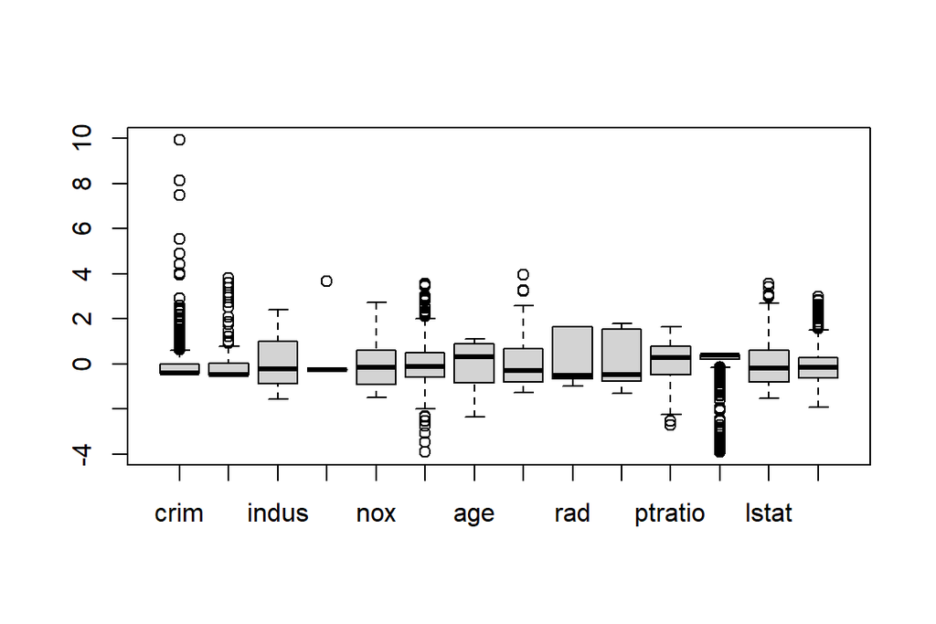

```r
boxplot(boston_scaled)
```

Before scaling, there was e.g. one variable (chas) with variation [0,1] and another (tax) with variation [187,711]. After scaling, the mean of all the variables is the same (0), and all the values of all the variables are between about -4 and 10.

Our aim in the next analysis is to predict crime rates of the suburb with other variables. In order to do this with linear discriminant analysis, variable ‘crim’ must be categorized. After categorization the old crim-variable will be replaced with the categorized one.

```r
summary(boston_scaled$crim)
```

```
##      Min.   1st Qu.    Median      Mean   3rd Qu.      Max.
## -0.419367 -0.410563 -0.390280  0.000000  0.007389  9.924110
```

```r
bins <- quantile(boston_scaled$crim)
name_bins <- c("low","med_low","med_high","high")
crime <- cut(boston_scaled$crim, breaks = bins, include.lowest = TRUE,label=name_bins)
table(crime)
```

```
## crime
##      low  med_low med_high     high
##      127      126      126      127
```

```r
boston_scaled <- dplyr::select(boston_scaled, -crim)
boston_scaled <- data.frame(boston_scaled, crime)
```

Because we used the quantiles as cut-points, every category has about as many observations. So the categorization succeeded,

Then the data will be split to train (80 %) and test (20 %) sets by first choosing randomly 80 % of the rows of the data, saving these to a new dataframe and then saving the rest of the rows to another dataframe. With test set it is possible to test the accuracy of the model that we’ll build later. For accuracy testing, the correct crime classes are saved as their own variable.

```r
n <- nrow(boston_scaled)

ind <- sample(n,  size = n * 0.8)

train <- boston_scaled[ind,]

test <- boston_scaled[-ind,]
```

## The LDA model

Now, we are ready to fit a linear discriminant analysis to the train set. The goal is to see, which variables separate the crimerate-classes the best.

```r
lda.fit <- lda(crime~., data = train)


lda.fit
```

```
## Call:
## lda(crime ~ ., data = train)
##
## Prior probabilities of groups:
##       low   med_low  med_high      high
## 0.2574257 0.2376238 0.2500000 0.2549505
##
## Group means:
##                   zn      indus        chas        nox          rm        age
## low       1.01160433 -0.8979480 -0.15875887 -0.8840876  0.37156443 -0.8833155
## med_low  -0.09375313 -0.2647014  0.01475116 -0.5480569 -0.15800896 -0.3616526
## med_high -0.38450487  0.2673640  0.31238879  0.4817131  0.04464111  0.4165038
## high     -0.48724019  1.0170891 -0.04298342  1.0626714 -0.39054182  0.8114230
##                 dis        rad        tax    ptratio       black       lstat
## low       0.9533412 -0.7013802 -0.7313308 -0.4036142  0.37569313 -0.75958134
## med_low   0.3808647 -0.5404292 -0.4749057 -0.1396842  0.31797642 -0.10958349
## med_high -0.4188409 -0.3928554 -0.2734628 -0.3434971  0.06926342  0.06291964
## high     -0.8441217  1.6384176  1.5142626  0.7811136 -0.75944523  0.87213991
##                 medv
## low       0.43804355
## med_low  -0.01002286
## med_high  0.13229149
## high     -0.67357531
##
## Coefficients of linear discriminants:
##                  LD1           LD2         LD3
## zn       0.100057429  0.7237003331 -1.02944540
## indus    0.028102401 -0.2521598800  0.21813108
## chas    -0.081370597 -0.1123656175  0.05382082
## nox      0.349568855 -0.6121249826 -1.26083462
## rm      -0.069222901 -0.0970510524 -0.16456908
## age      0.301215153 -0.1918007557 -0.21555137
## dis     -0.077194416 -0.1747127154  0.26992198
## rad      2.983114282  0.9923023210 -0.03790786
## tax      0.006488003 -0.1453058635  0.61213327
## ptratio  0.136480326  0.0764694292 -0.37421022
## black   -0.124205909  0.0003901995  0.10893033
## lstat    0.245879301 -0.2958114629  0.43304185
## medv     0.210224447 -0.3970203411 -0.12872920
##
## Proportion of trace:
##    LD1    LD2    LD3
## 0.9425 0.0432 0.0143
```

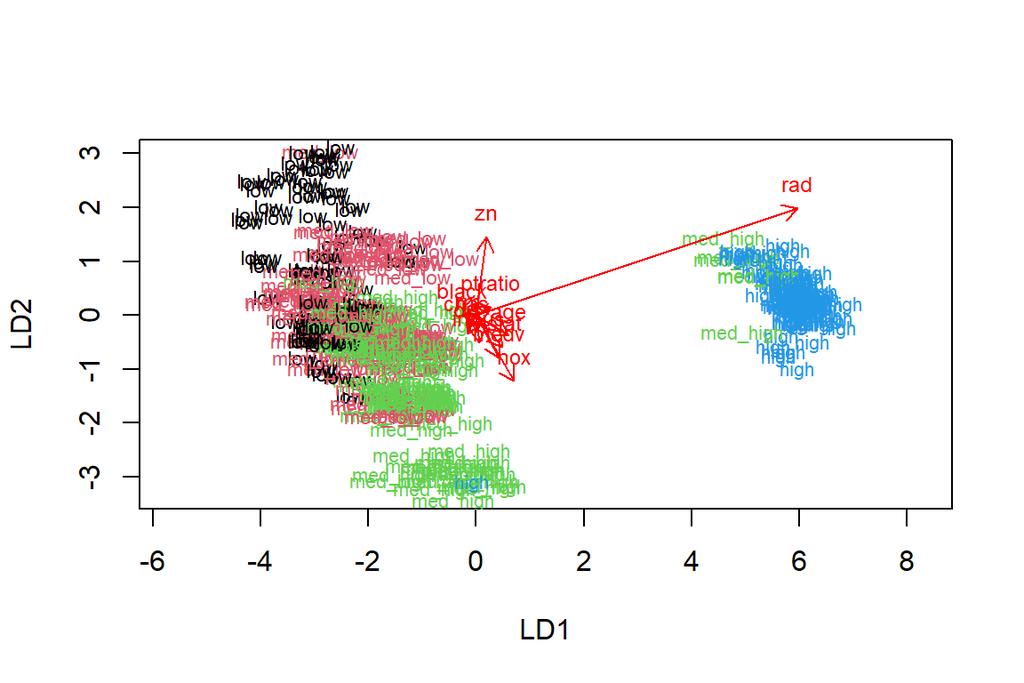

```r
lda.arrows <- function(x, myscale = 1, arrow_heads = 0.1, color = "red", tex = 0.75, choices = c(1,2)){
  heads <- coef(x)
  arrows(x0 = 0, y0 = 0,
         x1 = myscale * heads[,choices[1]],
         y1 = myscale * heads[,choices[2]], col=color, length = arrow_heads)
  text(myscale * heads[,choices], labels = row.names(heads),
       cex = tex, col=color, pos=3)
}

classes <- as.numeric(train$crime)

plot(lda.fit, dimen = 2, col=classes, pch=classes)
lda.arrows(lda.fit, myscale = 2
)
```

LD1 indicates the amount of variance between the groups explained by LD1 (about 95 %). If I understand right from the picture, in this model rad (an indication of accessibility) and zn (related to zoning) and nox (nitrogen oxides concentration) are the variables influencing the grouping the most.

## Prediction of the crime rate classes

Below, I’ll take the correct crime rate classes from the test dataset and save them as a new variable. Then, I delete the original classes from the test data. After this, I’ll predict crime rate classes with my LDA model, and compare the predicted vs. actual classes with a crosstable. After this I also made a dataframe comparing the correct and the predicted values and counted the percentage of correct predictions.

```r
correct_classes <- test$crime

test <- dplyr::select(test, -crime)

lda.pred <- predict(lda.fit, newdata = test)

table(correct = correct_classes, predicted = lda.pred$class)
```

```
##           predicted
## correct    low med_low med_high high
##   low       11      10        2    0
##   med_low    5      16        9    0
##   med_high   0       8       17    0
##   high       0       0        0   24
```

```r
row_names <- 1:102
corr_pred <- data.frame(correct = correct_classes, pred = lda.pred$class, row.names = row_names)
head(corr_pred)
```

```
##    correct     pred
## 1 med_high  med_low
## 2 med_high  med_low
## 3 med_high  med_low
## 4 med_high med_high
## 5 med_high med_high
## 6 med_high  med_low
```

```r
nrow(corr_pred[corr_pred$correct==corr_pred$pred,])/nrow(test)
```

```
## [1] 0.6666667
```

With these train and test sets, my LDA model predicts about 70 % of the crime rate classes correctly. Because the sets are formed randomly, with other sets the accuracy of the model might differ a little from this. I think the accuracy of the model is quite good when considering that in the number the almost-correctly-predicted (e.g. low vs med_low, med_high vs. high) are not included.

From LDA let’s move on to clustering. For this purpose we start again with Boston data and scale it. After scaling, the distances between the observations will be counted with Euclidian and Manhattan -methods. Distance measures indicate how different the observations are from each other.

```r
data(Boston)
new_boston <- scale(Boston)
class(new_boston)
```

```
## [1] "matrix" "array"
```

```r
new_boston <- as.data.frame(new_boston)

dist_eu <- dist(new_boston)
summary(dist_eu)
```

```
##    Min. 1st Qu.  Median    Mean 3rd Qu.    Max.
##  0.1343  3.4625  4.8241  4.9111  6.1863 14.3970
```

```r
dist_man <- dist(new_boston, method = "manhattan")
summary(dist_man)
```

```
##    Min. 1st Qu.  Median    Mean 3rd Qu.    Max.
##  0.2662  8.4832 12.6090 13.5488 17.7568 48.8618
```

From the summaries of the distances, I see that different methods produce different results.

Now I’ll run k-means algorithm on new_boston data and explore the results. I’ll start with the same amount of clusters that was set with LDA. After that, I set the maximum amount of clusters to be 10 and explore what is the optimal cluster amount (by calculating the total of within sum of squares, when the number of cluster goes from 1 to 10).

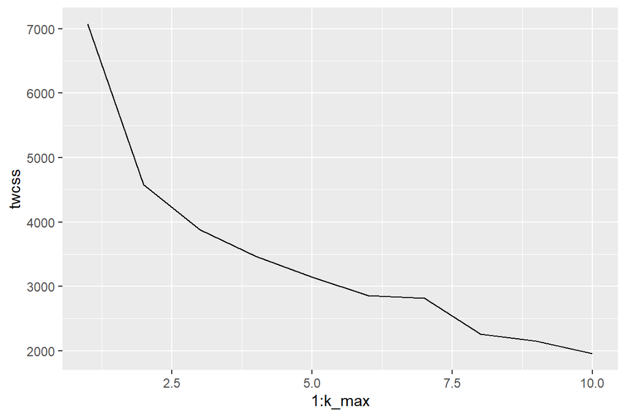

```r
km <-kmeans(new_boston, centers = 4)
set.seed(123)
k_max <- 10
twcss <- sapply(1:k_max, function(k){kmeans(new_boston, k)$tot.withinss})
qplot(x = 1:k_max, y = twcss, geom = 'line')
```

From the lineplot, the optimal number of clusters can be obtained by seeing where the line (i.e. the total of within sum of squares) drops radically. From this picture I see that 2 is the optimal number of clusters. So, next I’ll set the number of clusters to be 2 and then explore the model visually.

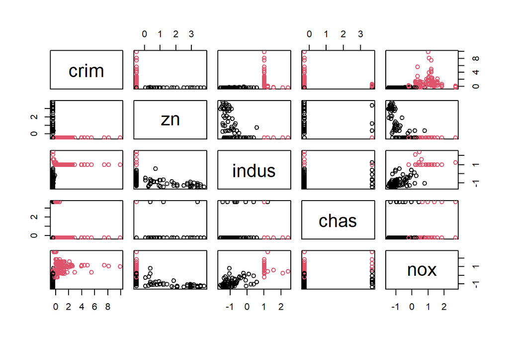

```r
km <-kmeans(new_boston, centers = 2)
pairs(new_boston[1:5], col = km$cluster)
```

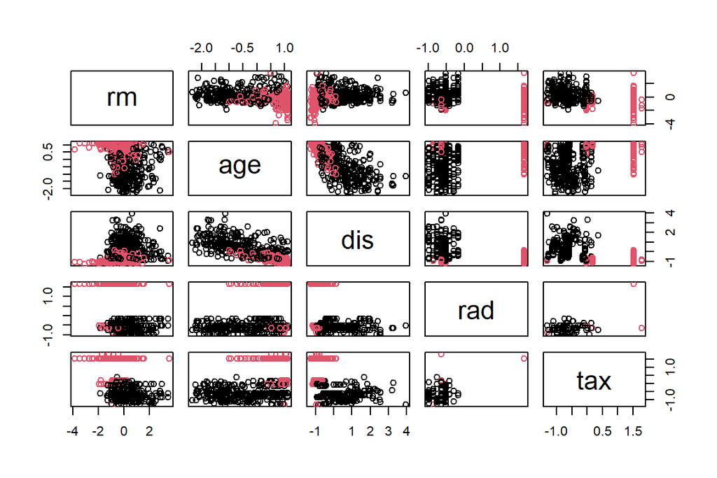

```r
pairs(new_boston[6:10], col = km$cluster)
```

If I understand the pictures correctly (of which I’m not confident), it seems that the variables indus, nox, age, dis, rad and tax seem to effect the clustering result i.e. separate the suburbs from each other. I give an example of how I interpreted the images: for example variable ‘indus’: it seems that for lower values of indus there is mostly color black and when the values of indus grow the color changes to red. The variables that seem to sort the suburbs are related to e.g. industry, accessibility and taxing.

Finally, the bonus exercise: clustering with k-means and then performing LDA for the resulted clusters. I run k-means with 4 clusters and save the clusters as their own column in the new_boston dataframe. Then i fit the LDA model for these clusters.

```r
data(Boston)
summary(new_boston)
```

```
##       crim                 zn               indus              chas
##  Min.   :-0.419367   Min.   :-0.48724   Min.   :-1.5563   Min.   :-0.2723
##  1st Qu.:-0.410563   1st Qu.:-0.48724   1st Qu.:-0.8668   1st Qu.:-0.2723
##  Median :-0.390280   Median :-0.48724   Median :-0.2109   Median :-0.2723
##  Mean   : 0.000000   Mean   : 0.00000   Mean   : 0.0000   Mean   : 0.0000
##  3rd Qu.: 0.007389   3rd Qu.: 0.04872   3rd Qu.: 1.0150   3rd Qu.:-0.2723
##  Max.   : 9.924110   Max.   : 3.80047   Max.   : 2.4202   Max.   : 3.6648
##       nox                rm               age               dis
##  Min.   :-1.4644   Min.   :-3.8764   Min.   :-2.3331   Min.   :-1.2658
##  1st Qu.:-0.9121   1st Qu.:-0.5681   1st Qu.:-0.8366   1st Qu.:-0.8049
##  Median :-0.1441   Median :-0.1084   Median : 0.3171   Median :-0.2790
##  Mean   : 0.0000   Mean   : 0.0000   Mean   : 0.0000   Mean   : 0.0000
##  3rd Qu.: 0.5981   3rd Qu.: 0.4823   3rd Qu.: 0.9059   3rd Qu.: 0.6617
##  Max.   : 2.7296   Max.   : 3.5515   Max.   : 1.1164   Max.   : 3.9566
##       rad               tax             ptratio            black
##  Min.   :-0.9819   Min.   :-1.3127   Min.   :-2.7047   Min.   :-3.9033
##  1st Qu.:-0.6373   1st Qu.:-0.7668   1st Qu.:-0.4876   1st Qu.: 0.2049
##  Median :-0.5225   Median :-0.4642   Median : 0.2746   Median : 0.3808
##  Mean   : 0.0000   Mean   : 0.0000   Mean   : 0.0000   Mean   : 0.0000
##  3rd Qu.: 1.6596   3rd Qu.: 1.5294   3rd Qu.: 0.8058   3rd Qu.: 0.4332
##  Max.   : 1.6596   Max.   : 1.7964   Max.   : 1.6372   Max.   : 0.4406
##      lstat              medv
##  Min.   :-1.5296   Min.   :-1.9063
##  1st Qu.:-0.7986   1st Qu.:-0.5989
##  Median :-0.1811   Median :-0.1449
##  Mean   : 0.0000   Mean   : 0.0000
##  3rd Qu.: 0.6024   3rd Qu.: 0.2683
##  Max.   : 3.5453   Max.   : 2.9865
```

```r
set.seed(123)
km <-kmeans(new_boston, centers = 4)
new_boston$cluster_num <- as.factor(km$cluster)
summary(new_boston$cluster_num)
```

```
##   1   2   3   4
##  42 127 125 212
```

```r
lda.fit.new <- lda(cluster_num~., data = new_boston)
lda.fit.new
```

```
## Call:
## lda(cluster_num ~ ., data = new_boston)
##
## Prior probabilities of groups:
##          1          2          3          4
## 0.08300395 0.25098814 0.24703557 0.41897233
##
## Group means:
##        crim         zn      indus         chas        nox         rm
## 1  1.916757 -0.4872402  1.0201311 -0.272329068  1.0484799 -0.4122561
## 2  0.392245 -0.4872402  1.1697122  0.099680403  1.1439383 -0.4650169
## 3 -0.398970  1.2614609 -0.9791535 -0.020354653 -0.8573235  1.0090468
## 4 -0.379470 -0.3553728 -0.3254942  0.006239345 -0.3875041 -0.2347120
##           age        dis        rad        tax      ptratio      black
## 1  0.78947129 -0.8908848  1.6076484  1.4922585  0.745290819 -2.8449572
## 2  0.80978018 -0.8411778  1.0202595  1.1728009  0.554458254  0.1236280
## 3 -0.96130713  0.9497716 -0.5867985 -0.6709807 -0.802391366  0.3552363
## 4 -0.07470041  0.1204023 -0.5836998 -0.6025848 -0.006695716  0.2801081
##        lstat       medv
## 1  1.2421501 -1.1216726
## 2  0.7233656 -0.5227308
## 3 -0.9571271  1.0666829
## 4 -0.1150795 -0.0935769
##
## Coefficients of linear discriminants:
##                  LD1         LD2         LD3
## crim    -0.286023125  0.80602402 -0.03333291
## zn      -0.089859575  0.13462263 -1.10231465
## indus   -0.735653415 -0.45789839 -0.28208393
## chas     0.017410931 -0.05012732  0.10429028
## nox     -0.899932933 -0.62685584 -0.88920386
## rm       0.097896063  0.23979626 -0.55810591
## age      0.109881276 -0.12193217  0.43714910
## dis     -0.003570884 -0.07345087 -0.37105427
## rad     -0.556638804 -0.13777523 -0.06560018
## tax     -0.784022250 -0.48969815 -0.63992730
## ptratio -0.345404084 -0.09075010 -0.08271930
## black    0.763101368 -1.86649503 -0.36582132
## lstat   -0.200448270  0.09690647 -0.40471029
## medv     0.054565330  0.12584075 -0.79189479
##
## Proportion of trace:
##    LD1    LD2    LD3
## 0.7012 0.1963 0.1025
```

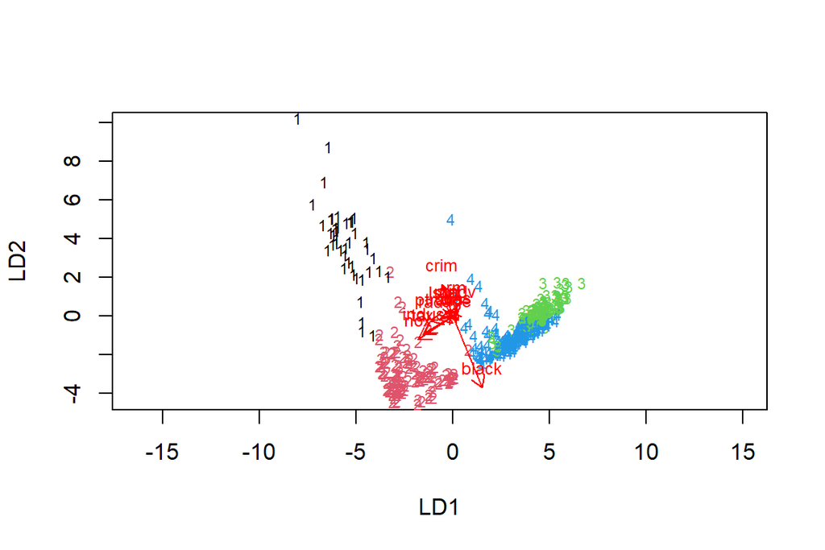

```r
lda.arrows <- function(x, myscale = 1, arrow_heads = 0.1, color = "red", tex = 0.75, choices = c(1,2)){
  heads <- coef(x)
  arrows(x0 = 0, y0 = 0,
         x1 = myscale * heads[,choices[1]],
         y1 = myscale * heads[,choices[2]], col=color, length = arrow_heads)
  text(myscale * heads[,choices], labels = row.names(heads),
       cex = tex, col=color, pos=3)
}

classes <- as.numeric(new_boston$cluster_num)

plot(lda.fit.new, dimen = 2, col=classes, pch=classes)
lda.arrows(lda.fit.new, myscale = 2
)
```

In this 4-cluster model I see that LD1 explains about 70 %, LD2 about 20 % and LD 3 about 10 % of the amount of variance between the groups. From the biplot I see that the variable that separates the groups best seems to be black (proportion of blacks is town), and also some separation power have crim, indus and nox.

## Concluding thought about the exercises this week:

I think that these exercises made it clear that with the same data, very different results can be obtained with different classification methods, and also wiht different times of running the analysis with the same method. Conducting different modelings on the data was very interesting.

# Report of exercise 5

During the last weeks I’ve noticed that through this course I’ve taken some steps forward with R: for example I manage to resolve some problems that occure during the exercises by reading R documentation or googling some examples. I also understand the code better and can do some minor adjustments to it when necessary. Obviously, there’s still so much to learn to become a more independent R user, but I’m on my way there (which I wasn’t so sure about before this course).

This week, the exercises felt pretty comprehensible and the interpretation of PCA was logical to me.

## Exploring the data (step 1)

First, I’ll access the necessary libraries and load the data. Then I’ll explore the dataset - all the variables and observations are in place. After this I’ll explore the distributions and relations of the variables.

```r
library(dplyr)
library(GGally)
library(corrplot)
human <- read.csv("data/human.csv", row.names = 1)

dim(human)
```

```
## [1] 155   8
```

```r
head(human)
```

```
##              eduratio  labratio Edu.exp Life.exp   GNI Mat.mor Ado.BR Parl.rep
## Norway      1.0072389 0.8908297    17.5     81.6 64992       4    7.8     39.6
## Australia   0.9968288 0.8189415    20.2     82.4 42261       6   12.1     30.5
## Switzerland 0.9834369 0.8251001    15.8     83.0 56431       6    1.9     28.5
## Denmark     0.9886128 0.8840361    18.7     80.2 44025       5    5.1     38.0
## Netherlands 0.9690608 0.8286119    17.9     81.6 45435       6    6.2     36.9
## Germany     0.9927835 0.8072289    16.5     80.9 43919       7    3.8     36.9
```

```r
summary(human)
```

```
##     eduratio         labratio         Edu.exp         Life.exp
##  Min.   :0.1717   Min.   :0.1857   Min.   : 5.40   Min.   :49.00
##  1st Qu.:0.7264   1st Qu.:0.5984   1st Qu.:11.25   1st Qu.:66.30
##  Median :0.9375   Median :0.7535   Median :13.50   Median :74.20
##  Mean   :0.8529   Mean   :0.7074   Mean   :13.18   Mean   :71.65
##  3rd Qu.:0.9968   3rd Qu.:0.8535   3rd Qu.:15.20   3rd Qu.:77.25
##  Max.   :1.4967   Max.   :1.0380   Max.   :20.20   Max.   :83.50
##       GNI            Mat.mor           Ado.BR          Parl.rep
##  Min.   :   581   Min.   :   1.0   Min.   :  0.60   Min.   : 0.00
##  1st Qu.:  4198   1st Qu.:  11.5   1st Qu.: 12.65   1st Qu.:12.40
##  Median : 12040   Median :  49.0   Median : 33.60   Median :19.30
##  Mean   : 17628   Mean   : 149.1   Mean   : 47.16   Mean   :20.91
##  3rd Qu.: 24512   3rd Qu.: 190.0   3rd Qu.: 71.95   3rd Qu.:27.95
##  Max.   :123124   Max.   :1100.0   Max.   :204.80   Max.   :57.50
```

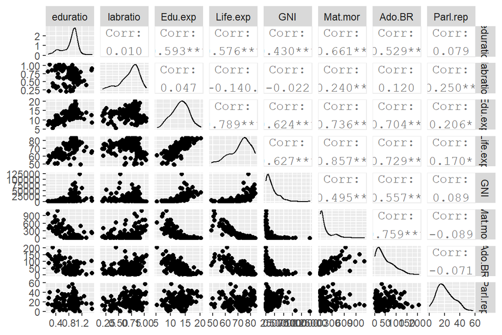

```r
ggpairs(human)
```

```r
cor_matrix_<-cor(human) %>% round(digits=2)
cor_matrix_
```

```
##          eduratio labratio Edu.exp Life.exp   GNI Mat.mor Ado.BR Parl.rep
## eduratio     1.00     0.01    0.59     0.58  0.43   -0.66  -0.53     0.08
## labratio     0.01     1.00    0.05    -0.14 -0.02    0.24   0.12     0.25
## Edu.exp      0.59     0.05    1.00     0.79  0.62   -0.74  -0.70     0.21
## Life.exp     0.58    -0.14    0.79     1.00  0.63   -0.86  -0.73     0.17
## GNI          0.43    -0.02    0.62     0.63  1.00   -0.50  -0.56     0.09
## Mat.mor     -0.66     0.24   -0.74    -0.86 -0.50    1.00   0.76    -0.09
## Ado.BR      -0.53     0.12   -0.70    -0.73 -0.56    0.76   1.00    -0.07
## Parl.rep     0.08     0.25    0.21     0.17  0.09   -0.09  -0.07     1.00
```

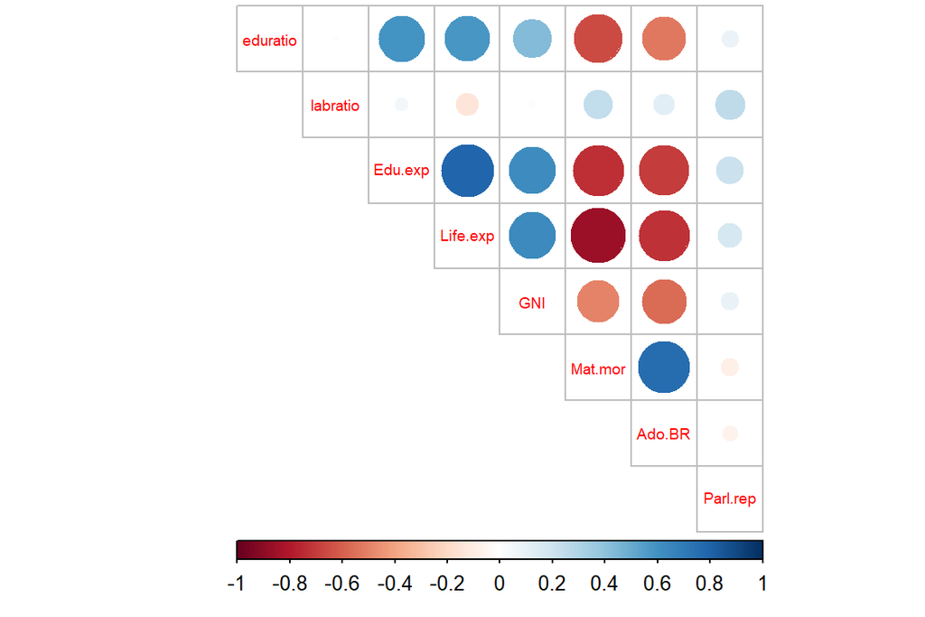

```r
corrplot(cor_matrix_, method="circle", type="upper", cl.pos="b",tl.pos="d",tl.cex=0.6)
```

### Distributions of the variables:

From summary I see that the variables are of very different scales. From ggpairs-picture I see that many of the variables are skewed:

- skewed to the lower end of the distribution: GNI, Mat.mor, Ado.BR, Parl.rep
- skewed to the upper end of the distribution: labratio, Life.exp
- not very skewed: eduratio, Edu.exp

### Relations between the variables:

From correlation matrix and corrplot I see that there are a lot of correlations between the variables. The strongest positive correlations are between:

- Ado.BR - Mar.mor
- Edu.exp - Life.exp

And the strongest negative correlations are between:

- Life.exp - Mat.mor
- Life.exp - Ado.BR
- Edu.exp - Mat.mor
- Edu.exp - Ado.BR

Variables *Parl.rep* and *labratio* don’t have very strong correlation with any of the other variables.

Next, I’ll move to the analysis part.

## PCA with non-standardized data (step 2)

```r
pca_human <- prcomp(human)
pca_human
```

```
## Standard deviations (1, .., p=8):
## [1] 1.854416e+04 1.855219e+02 2.518701e+01 1.145441e+01 3.766241e+00
## [6] 1.565912e+00 1.912052e-01 1.591112e-01
##
## Rotation (n x k) = (8 x 8):
##                    PC1           PC2           PC3           PC4           PC5
## eduratio -5.607472e-06  0.0006713951 -3.412027e-05 -2.736326e-04 -0.0022935252
## labratio  2.331945e-07 -0.0002819357  5.302884e-04 -4.692578e-03  0.0022190154
## Edu.exp  -9.562910e-05  0.0075529759  1.427664e-02 -3.313505e-02  0.1431180282
## Life.exp -2.815823e-04  0.0283150248  1.294971e-02 -6.752684e-02  0.9865644425
## GNI      -9.999832e-01 -0.0057723054 -5.156742e-04  4.932889e-05 -0.0001135863
## Mat.mor   5.655734e-03 -0.9916320120  1.260302e-01 -6.100534e-03  0.0266373214
## Ado.BR    1.233961e-03 -0.1255502723 -9.918113e-01  5.301595e-03  0.0188618600
## Parl.rep -5.526460e-05  0.0032317269 -7.398331e-03 -9.971232e-01 -0.0716401914
##                    PC6           PC7           PC8
## eduratio  2.180183e-02  6.998623e-01  7.139410e-01
## labratio  3.264423e-02  7.132267e-01 -7.001533e-01
## Edu.exp   9.882477e-01 -3.826887e-02  7.776451e-03
## Life.exp -1.453515e-01  5.380452e-03  2.281723e-03
## GNI      -2.711698e-05 -8.075191e-07 -1.176762e-06
## Mat.mor   1.695203e-03  1.355518e-04  8.371934e-04
## Ado.BR    1.273198e-02 -8.641234e-05 -1.707885e-04
## Parl.rep -2.309896e-02 -2.642548e-03  2.680113e-03
```

```r
summary(pca_human)
```

```
## Importance of components:
##                              PC1      PC2   PC3   PC4   PC5   PC6    PC7    PC8
## Standard deviation     1.854e+04 185.5219 25.19 11.45 3.766 1.566 0.1912 0.1591
## Proportion of Variance 9.999e-01   0.0001  0.00  0.00 0.000 0.000 0.0000 0.0000
## Cumulative Proportion  9.999e-01   1.0000  1.00  1.00 1.000 1.000 1.0000 1.0000
```

```r
s0 <- summary(pca_human)
s0
```

```
## Importance of components:
##                              PC1      PC2   PC3   PC4   PC5   PC6    PC7    PC8
## Standard deviation     1.854e+04 185.5219 25.19 11.45 3.766 1.566 0.1912 0.1591
## Proportion of Variance 9.999e-01   0.0001  0.00  0.00 0.000 0.000 0.0000 0.0000
## Cumulative Proportion  9.999e-01   1.0000  1.00  1.00 1.000 1.000 1.0000 1.0000
```

```r
pca_pr <- round(100*s0$importance[2, ], digits = 1)
pca_pr
```

```
## PC1 PC2 PC3 PC4 PC5 PC6 PC7 PC8
## 100   0   0   0   0   0   0   0
```

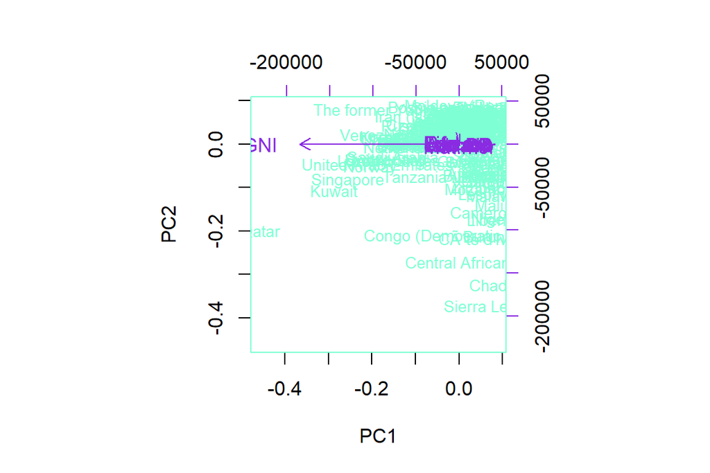

```r
pc_lab <- paste0(names(pca_pr), " (", pca_pr, "%)")
biplot(pca_human, choices = 1:2, cex = c(0.8,1), col = c("aquamarine", "blueviolet", xlab = pc_lab[1], ylab = pc_lab[2]))
```

## PCA with standardized data (step 3)

First, I’ll standardize the variables and check that the standardization went ok. Then I’ll conduct PCA with the standardized data and take the summary and see the percentages of variance captured by the model. After this I’ll draw a biplot with variance information on the axes.

```r
human_std <- scale(human)
summary(human_std)
```

```
##     eduratio          labratio          Edu.exp           Life.exp
##  Min.   :-2.8189   Min.   :-2.6247   Min.   :-2.7378   Min.   :-2.7188
##  1st Qu.:-0.5233   1st Qu.:-0.5484   1st Qu.:-0.6782   1st Qu.:-0.6425
##  Median : 0.3503   Median : 0.2316   Median : 0.1140   Median : 0.3056
##  Mean   : 0.0000   Mean   : 0.0000   Mean   : 0.0000   Mean   : 0.0000
##  3rd Qu.: 0.5958   3rd Qu.: 0.7350   3rd Qu.: 0.7126   3rd Qu.: 0.6717
##  Max.   : 2.6646   Max.   : 1.6632   Max.   : 2.4730   Max.   : 1.4218
##       GNI             Mat.mor            Ado.BR           Parl.rep
##  Min.   :-0.9193   Min.   :-0.6992   Min.   :-1.1325   Min.   :-1.8203
##  1st Qu.:-0.7243   1st Qu.:-0.6496   1st Qu.:-0.8394   1st Qu.:-0.7409
##  Median :-0.3013   Median :-0.4726   Median :-0.3298   Median :-0.1403
##  Mean   : 0.0000   Mean   : 0.0000   Mean   : 0.0000   Mean   : 0.0000
##  3rd Qu.: 0.3712   3rd Qu.: 0.1932   3rd Qu.: 0.6030   3rd Qu.: 0.6127
##  Max.   : 5.6890   Max.   : 4.4899   Max.   : 3.8344   Max.   : 3.1850
```

```r
pca_human_std <- prcomp(human_std)
pca_human_std
```

```
## Standard deviations (1, .., p=8):
## [1] 2.0708380 1.1397204 0.8750485 0.7788630 0.6619563 0.5363061 0.4589994
## [8] 0.3222406
##
## Rotation (n x k) = (8 x 8):
##                  PC1         PC2         PC3         PC4        PC5         PC6
## eduratio -0.35664370  0.03796058 -0.24223089  0.62678110 -0.5983585  0.17713316
## labratio  0.05457785  0.72432726 -0.58428770  0.06199424  0.2625067 -0.03500707
## Edu.exp  -0.42766720  0.13940571 -0.07340270 -0.07020294  0.1659678 -0.38606919
## Life.exp -0.44372240 -0.02530473  0.10991305 -0.05834819  0.1628935 -0.42242796
## GNI      -0.35048295  0.05060876 -0.20168779 -0.72727675 -0.4950306  0.11120305
## Mat.mor   0.43697098  0.14508727 -0.12522539 -0.25170614 -0.1800657  0.17370039
## Ado.BR    0.41126010  0.07708468  0.01968243  0.04986763 -0.4672068 -0.76056557
## Parl.rep -0.08438558  0.65136866  0.72506309  0.01396293 -0.1523699  0.13749772
##                  PC7         PC8
## eduratio  0.05773644  0.16459453
## labratio -0.22729927 -0.07304568
## Edu.exp   0.77962966 -0.05415984
## Life.exp -0.43406432  0.62737008
## GNI      -0.13711838 -0.16961173
## Mat.mor   0.35380306  0.72193946
## Ado.BR   -0.06897064 -0.14335186
## Parl.rep  0.00568387 -0.02306476
```

```r
s <- summary(pca_human_std)
s
```

```
## Importance of components:
##                           PC1    PC2     PC3     PC4     PC5     PC6     PC7
## Standard deviation     2.0708 1.1397 0.87505 0.77886 0.66196 0.53631 0.45900
## Proportion of Variance 0.5361 0.1624 0.09571 0.07583 0.05477 0.03595 0.02634
## Cumulative Proportion  0.5361 0.6984 0.79413 0.86996 0.92473 0.96069 0.98702
##                            PC8
## Standard deviation     0.32224
## Proportion of Variance 0.01298
## Cumulative Proportion  1.00000
```

```r
pca_std_pr <- round(100*s$importance[2, ], digits = 1)
pca_std_pr
```

```
##  PC1  PC2  PC3  PC4  PC5  PC6  PC7  PC8
## 53.6 16.2  9.6  7.6  5.5  3.6  2.6  1.3
```

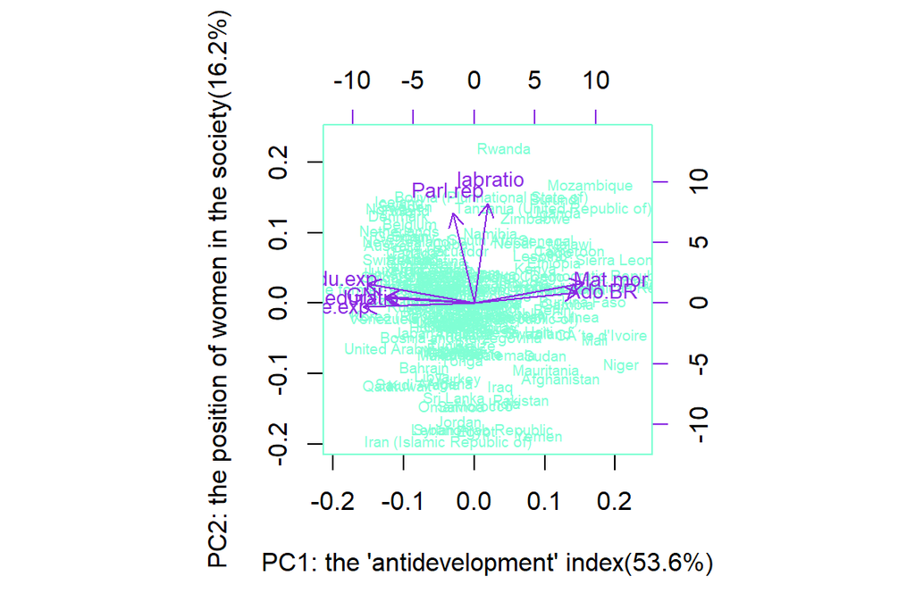

```r
pc_lab_std1 <- paste0("PC1: the 'antidevelopment' index", "(", pca_std_pr[1], "%)")

pc_lab_std2 <- paste0("PC2: the position of women in the society", "(", pca_std_pr[2], "%)")

biplot(pca_human_std, cex = c(0.6, 0.8), col = c("aquamarine", "blueviolet"), xlab = pc_lab_std1, ylab = pc_lab_std2)
```

Overall, I can see that the results of the two analysis differ very much, and below I will take a closer look on both analysis and explain where the difference comes from.

### Interpretation of the model with non-standardized data

With these non-standardized variables the analysis doesn’t seem to work very well. The first principal component captures practically all of the variability, and variable *GNI* correlates completely with that component. When I see the scales of the variables I see that *GNI* values are of a much larger scale than any of the other variables, and this is why it is weighted so much in the analysis. Conclusion: With the non-standardized variables PCA doesn’t serve its purpose: this analysis doesn’t squeeze up the information of many variables, it only shows the distribution of observations based on the largest-scale variable.

### Interpretation of the model with standardized data

PC1 captures ~54 % of the variability of the data, PC2 ~16 %, PC3 ~10% and PC4 ~8%. The number of components to include in the model is a tricky question, since there is no rule about which criteria should be applied. Using criteria that the total variance explained by the model should be something between 70-90 %, I would include 2 (almost 70 % of explained variance) 3 (79 %) or 4 (87 %) components. The two-component solution was quite easy to interpret, so that would pull on that side, but I am not sure if this is a relevant basis for the choice.

## Interpretation of the first two principal component dimensions with standardized data (Step 4)

From the biplot I see that the first component correlates strongly and positively with *adolescent birth rate* and *maternal mortality rate* and has strong negative correlations with *life expectancy*, *expected years of schooling*, *GNI* and *proportion of females vs. males receiving secondary education*. Thus, the first component seems to be somewhat general index for “antidevelopment” of countries: the more a country has points in this component, the less it is developed. The second principal component correlates with *proportion of females vs. males in the labour force* and *percetage of female representatives in parliament*, so it seems to indicate the position of women in the society: the more points a country has on this component, the more women get to participate in the societal actions (of course this is a simplification based on these variables). The variables are correlated with the components and each other as could be predicted from the initial correlations: *Parl.rep* and *labratio* didn’t correlate much with the other variables.

Let’s also take a look at how the countries are situated in the picture. In the upper left side of the picture are “the most developed and equal countries”, like many of the Northern countries. Respectively, in the bottom right side are the least developed and not equal countries like Mauritania, Afghanistan, Niger and Yemen. In the bottom part of the picture are those countries where women don’t get to participate to the society very much, and logically there are e.g. many Arabic countries. In the upper section of the picture there are countries in which women participate a lot in the society, and somewhat surprisingly there are many African countries (and not so surprisingly many Europian countries also).

## Tea dataset and MCA (step 5)

First, I’ll access the necessary libraries, select the columns that I find interesting, and then explore the distributions of the variables.

```r
library(FactoMineR)
```

```r
library(ggplot2)
library(dplyr)
library(tidyr)
data(tea)
str(tea)
```

```
## 'data.frame':    300 obs. of  36 variables:
##  $ breakfast       : Factor w/ 2 levels "breakfast","Not.breakfast": 1 1 2 2 1 2 1 2 1 1 ...
##  $ tea.time        : Factor w/ 2 levels "Not.tea time",..: 1 1 2 1 1 1 2 2 2 1 ...
##  $ evening         : Factor w/ 2 levels "evening","Not.evening": 2 2 1 2 1 2 2 1 2 1 ...
##  $ lunch           : Factor w/ 2 levels "lunch","Not.lunch": 2 2 2 2 2 2 2 2 2 2 ...
##  $ dinner          : Factor w/ 2 levels "dinner","Not.dinner": 2 2 1 1 2 1 2 2 2 2 ...
##  $ always          : Factor w/ 2 levels "always","Not.always": 2 2 2 2 1 2 2 2 2 2 ...
##  $ home            : Factor w/ 2 levels "home","Not.home": 1 1 1 1 1 1 1 1 1 1 ...
##  $ work            : Factor w/ 2 levels "Not.work","work": 1 1 2 1 1 1 1 1 1 1 ...
##  $ tearoom         : Factor w/ 2 levels "Not.tearoom",..: 1 1 1 1 1 1 1 1 1 2 ...
##  $ friends         : Factor w/ 2 levels "friends","Not.friends": 2 2 1 2 2 2 1 2 2 2 ...
##  $ resto           : Factor w/ 2 levels "Not.resto","resto": 1 1 2 1 1 1 1 1 1 1 ...
##  $ pub             : Factor w/ 2 levels "Not.pub","pub": 1 1 1 1 1 1 1 1 1 1 ...
##  $ Tea             : Factor w/ 3 levels "black","Earl Grey",..: 1 1 2 2 2 2 2 1 2 1 ...
##  $ How             : Factor w/ 4 levels "alone","lemon",..: 1 3 1 1 1 1 1 3 3 1 ...
```

[output cut: 22 more lines]

```r
keep_columns <- c("Tea", "How", "breakfast", "work", "where", "sex")
tea_time <- dplyr::select(tea, one_of(keep_columns))
str(tea_time)
```

```
## 'data.frame':    300 obs. of  6 variables:
##  $ Tea      : Factor w/ 3 levels "black","Earl Grey",..: 1 1 2 2 2 2 2 1 2 1 ...
##  $ How      : Factor w/ 4 levels "alone","lemon",..: 1 3 1 1 1 1 1 3 3 1 ...
##  $ breakfast: Factor w/ 2 levels "breakfast","Not.breakfast": 1 1 2 2 1 2 1 2 1 1 ...
##  $ work     : Factor w/ 2 levels "Not.work","work": 1 1 2 1 1 1 1 1 1 1 ...
##  $ where    : Factor w/ 3 levels "chain store",..: 1 1 1 1 1 1 1 1 2 2 ...
##  $ sex      : Factor w/ 2 levels "F","M": 2 1 1 2 2 2 2 1 2 2 ...
```

```r
dim(tea_time)
```

```
## [1] 300   6
```

```r
summary(tea_time)
```

```
##         Tea         How              breakfast         work
##  black    : 74   alone:195   breakfast    :144   Not.work:213
##  Earl Grey:193   lemon: 33   Not.breakfast:156   work    : 87
##  green    : 33   milk : 63
##                  other:  9
##                   where     sex
##  chain store         :192   F:178
##  chain store+tea shop: 78   M:122
##  tea shop            : 30
##
```

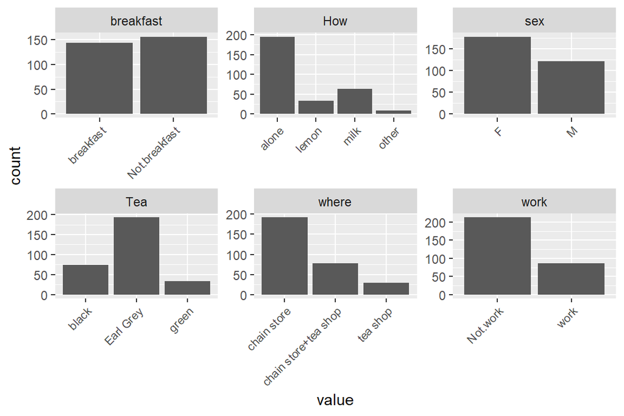

```r
gather(tea_time) %>% ggplot(aes(value)) + facet_wrap("key", scales = "free") + geom_bar() + theme(axis.text.x = element_text(angle = 45, hjust = 1, size = 8))
```

### Exploration of the variables:

There are now six variables and 300 observations (people). All the variables are categorical.

My comments on the distributions of the variables:

- breakfast: In this sample, there are almost as many people that drink tea in the morning as those who don’t.
- How: Most of the people in this sample drink their tea without add-ons. The most popular add-on is milk.
- sex: There are a bit more women than men in this sample.
- Tea: The most popular tea quality in this sample is Earl Grey.
- where: The most of the people in this sample by their teas from chain stores.
- work: Most of the people in this sample don’t drink tea at work.

### MCA

Next, I’ll perform MCA for the subset of the tea-data, see the summary of the model and then draw biplots with first the variables and then the individuals.

```r
mca <- MCA(tea_time, graph = FALSE)
summary(mca)
```

```
##
## Call:
## MCA(X = tea_time, graph = FALSE)
##
##
## Eigenvalues
##                        Dim.1   Dim.2   Dim.3   Dim.4   Dim.5   Dim.6   Dim.7
## Variance               0.253   0.216   0.202   0.191   0.151   0.145   0.137
## % of var.             15.161  12.982  12.143  11.445   9.074   8.675   8.248
## Cumulative % of var.  15.161  28.143  40.287  51.731  60.805  69.480  77.727
##                        Dim.8   Dim.9  Dim.10
## Variance               0.133   0.123   0.115
## % of var.              8.004   7.381   6.888
## Cumulative % of var.  85.731  93.112 100.000
##
## Individuals (the 10 first)
##                  Dim.1    ctr   cos2    Dim.2    ctr   cos2    Dim.3    ctr
## 1             | -0.192  0.048  0.031 |  0.600  0.555  0.304 | -0.492  0.399
## 2             |  0.265  0.093  0.044 |  0.561  0.484  0.197 | -0.671  0.741
## 3             |  0.086  0.010  0.008 | -0.760  0.890  0.607 | -0.036  0.002
## 4             | -0.463  0.283  0.290 | -0.161  0.040  0.035 | -0.136  0.031
## 5             | -0.173  0.040  0.039 |  0.052  0.004  0.004 | -0.327  0.176
## 6             | -0.463  0.283  0.290 | -0.161  0.040  0.035 | -0.136  0.031
## 7             | -0.173  0.040  0.039 |  0.052  0.004  0.004 | -0.327  0.176
## 8             | -0.025  0.001  0.000 |  0.348  0.186  0.077 | -0.481  0.380
## 9             |  0.518  0.354  0.159 |  0.545  0.457  0.176 | -0.122  0.025
## 10            |  0.206  0.056  0.027 |  0.711  0.779  0.323 | -0.112  0.021
##                 cos2
## 1              0.205 |
## 2              0.283 |
## 3              0.001 |
## 4              0.025 |
## 5              0.139 |
## 6              0.025 |
## 7              0.139 |
## 8              0.148 |
## 9              0.009 |
## 10             0.008 |
##
## Categories (the 10 first)
```

[output cut: 16 more lines]

```
## lemon           1.172 |   2.104  40.107   0.547  12.792 |
## milk            6.432 |  -0.622   6.696   0.103  -5.547 |
## other           5.118 |  -0.146   0.053   0.001  -0.445 |
## breakfast       5.135 |  -0.267   2.820   0.066  -4.437 |
## Not.breakfast  -5.135 |   0.247   2.603   0.066   4.437 |
## Not.work        3.906 |  -0.081   0.385   0.016  -2.197 |
##
## Categorical variables (eta2)
##                 Dim.1 Dim.2 Dim.3
## Tea           | 0.337 0.430 0.044 |
## How           | 0.256 0.275 0.583 |
## breakfast     | 0.191 0.088 0.066 |
## work          | 0.280 0.051 0.016 |
## where         | 0.393 0.121 0.505 |
## sex           | 0.058 0.333 0.000 |
```

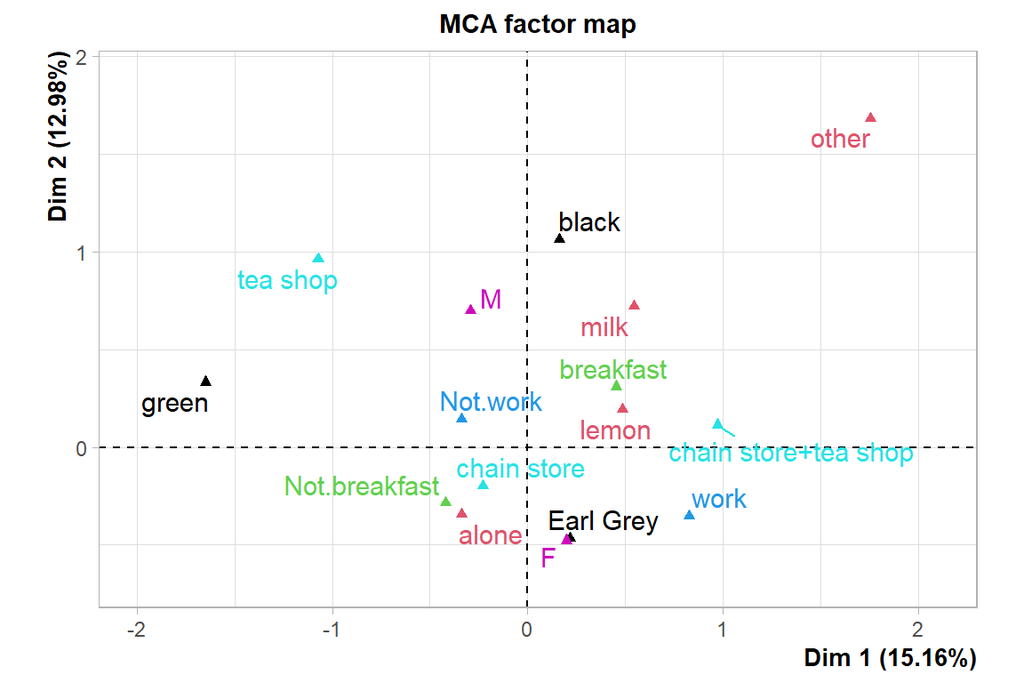

```r
plot(mca, invisible=c("ind"), habillage = "quali")
```

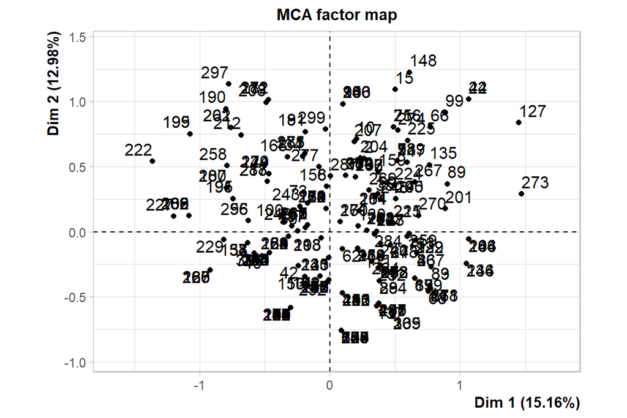

```r
plot(mca, invisible=c("var"))
```

### Interpretation of the model:

I find it difficult to make any “overall” interpretation from this model or plots. This might be because none of the dimensions explains a large proportion of the variability in the data - the first dimension explains only ~15 % and the second ~13 %, together ~28 %. From the biplot of the variables I see that e.g. drinking green tea and buying teas from teashop are related. Men seem to consume more black tea and women earl grey. Those who buy teas from chain stores, don’t usually drink it on breakfast, and mostly drink their tea alone. The biplot of individuals doesn’t show any specific groups (the individuals are pretty equally distributed around the two dimensions) and thus no interpretation can be made (or at least I can’t figure out one). Maybe the overall conclusion is that this MCA-analysis didn’t help much in squeezing up the information of these six variables since the proportion of variance explained by first six dimensions is only ~69 %.

# Report of exercise 6

This week I only had time for the course exercises in the evenings after my working days. I also found this topic somewhat more complicated than many of the other topics in this course, so the combination of too little time and a difficult topic wasn’t very good. However, I did a lot of work and got approximately everything done, and for that I’m glad. I did my best with the interpretations, but of course I am not very confident with those.

All in all, I think I have learned so much during this course and I am keen to take all these ideas with me when I conduct my doctoral dissertation.

## RATS

First, I access the necessary libraries, read the RATSL-data to R and convert ID and Group variables to factors.

```r
library(dplyr)
library(tidyr)
library(ggplot2)
library(lme4)
RATS <- read.table("https://raw.githubusercontent.com/KimmoVehkalahti/MABS/master/Examples/data/rats.txt", header = TRUE, sep = '\t')

RATSL <- read.csv("data/RATSL.csv", row.names = 1)
head(RATSL)
```

```
##   ID Group  WD Weight Time
## 1  1     1 WD1    240    1
## 2  2     1 WD1    225    1
## 3  3     1 WD1    245    1
## 4  4     1 WD1    260    1
## 5  5     1 WD1    255    1
## 6  6     1 WD1    260    1
```

```r
RATSL <- RATSL %>% mutate(ID = as.factor(RATSL$ID)) %>% mutate(Group = as.factor(RATSL$Group))
str(RATSL)
```

```
## 'data.frame':    176 obs. of  5 variables:
##  $ ID    : Factor w/ 16 levels "1","2","3","4",..: 1 2 3 4 5 6 7 8 9 10 ...
##  $ Group : Factor w/ 3 levels "1","2","3": 1 1 1 1 1 1 1 1 2 2 ...
##  $ WD    : chr  "WD1" "WD1" "WD1" "WD1" ...
##  $ Weight: int  240 225 245 260 255 260 275 245 410 405 ...
##  $ Time  : int  1 1 1 1 1 1 1 1 1 1 ...
```

```r
head(RATSL)
```

```
##   ID Group  WD Weight Time
## 1  1     1 WD1    240    1
## 2  2     1 WD1    225    1
## 3  3     1 WD1    245    1
## 4  4     1 WD1    260    1
## 5  5     1 WD1    255    1
## 6  6     1 WD1    260    1
```

The RATSL data contains measurements of weight development of rats (n = 16) during a 9-week period with three different diets. The data is converted to long form in which each measurement of each rat is on its own row. The purpose is to study whether the weight of rats develops in a different way with different diets.

Next, I draw a plot depicting the weight development in different diet groups.

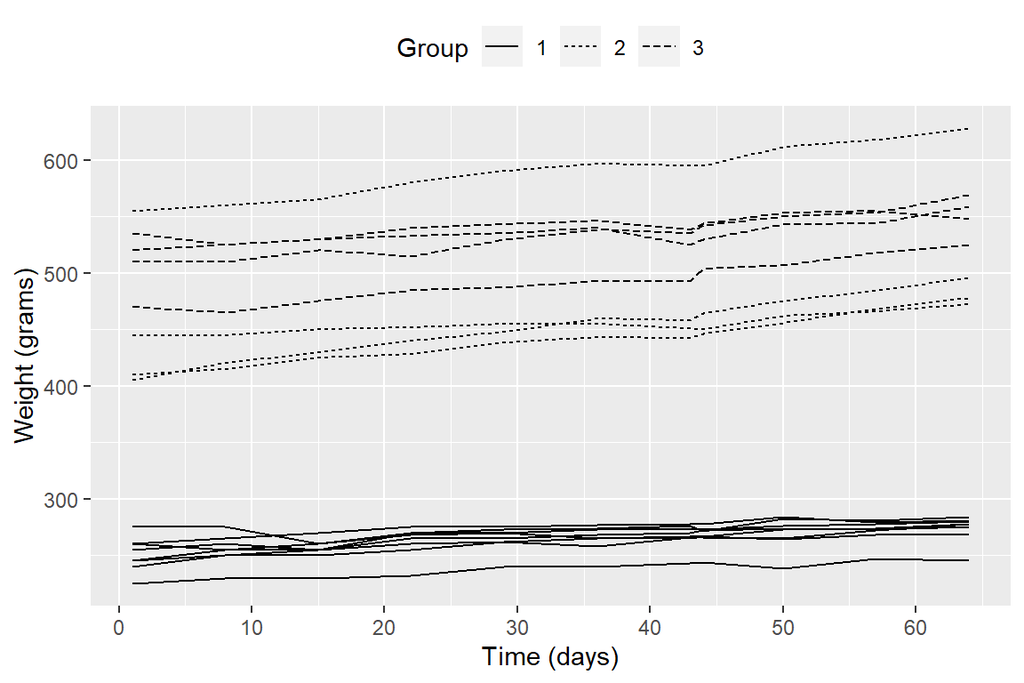

```r
ggplot(RATSL, aes(x = Time, y = Weight, group = ID)) +
  geom_line(aes(linetype=Group)) +
  scale_x_continuous(name = "Time (days)", breaks = seq(0, 60, 10)) +
   scale_y_continuous(name = "Weight (grams)") +
   theme(legend.position = "top")
```

In this plot, we see the development of weight of each rat in the three diet groups. From the plot I notice that the mean initial weights vary between the groups: the weights of rats on diet 1 are initially much smaller than the weights of rats on diets 2 and 3. Roughly evaluating, the weights of rats on diets 2 and 3 grow maybe faster than the weights of rats on diet 1. Now, I’ll conduct the standardization of the weights.

```r
RATSL <- RATSL %>%
  group_by(Time) %>%
  mutate(stdweight = (Weight-mean(Weight))/sd(Weight)) %>%
  ungroup()

glimpse(RATSL)
```

```
## Rows: 176
## Columns: 6
## $ ID        <fct> 1, 2, 3, 4, 5, 6, 7, 8, 9, 10, 11, 12, 13, 14, 15, 16, 1,...
## $ Group     <fct> 1, 1, 1, 1, 1, 1, 1, 1, 2, 2, 2, 2, 3, 3, 3, 3, 1, 1, 1, ...
## $ WD        <chr> "WD1", "WD1", "WD1", "WD1", "WD1", "WD1", "WD1", "WD1", "...
## $ Weight    <int> 240, 225, 245, 260, 255, 260, 275, 245, 410, 405, 445, 55...
## $ Time      <int> 1, 1, 1, 1, 1, 1, 1, 1, 1, 1, 1, 1, 1, 1, 1, 1, 8, 8, 8, ...
## $ stdweight <dbl> -1.0011429, -1.1203857, -0.9613953, -0.8421525, -0.881900...
```

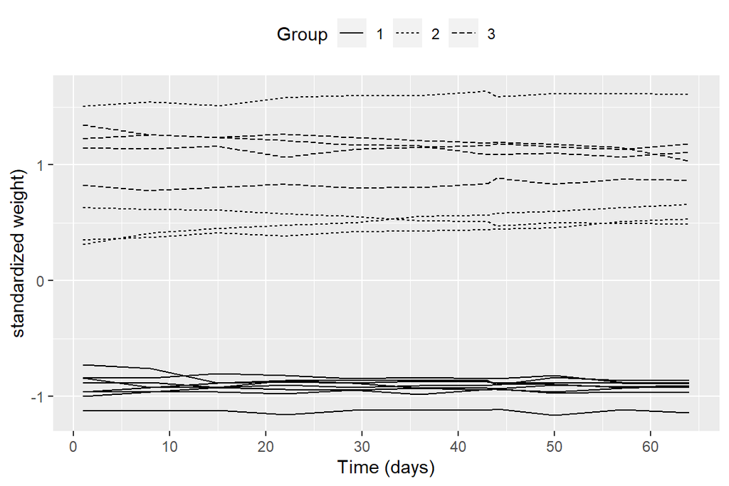

```r
ggplot(RATSL, aes(x = Time, y = stdweight, group = ID)) +
  geom_line(aes(linetype=Group)) +
  scale_x_continuous(name = "Time (days)", breaks = seq(0, 60, 10)) +
   scale_y_continuous(name = "standardized weight)") +
   theme(legend.position = "top")
```

In this plot of standardized weights, we see the development of the weight of each rat in the three diet groups compared to the average weight gain of all the rats at each time point. From this standardization I see that the weights of rats on diet 1 are approximately one standard deviation below average from beginning to end. If I understand correctly, horizontal line means that the weight of the rat develops at an average rate on that period; if the line goes downwards the weight of the rat develops slower than average on that period; and if the line goes upwards the weight of that rat develops faster than average on that period. Overall, it seems that the lines of diet group 2 go a little upwards, and the lines of diet groups 1 and 3 go horizontally or (for some of the rats) a little downwards. So, the weights of group 2 rats might develop a little faster than the weights of the rats in the other two groups.

```r
n <- RATSL$Time %>% unique() %>% length()
RATSS <- RATSL %>%
  group_by(Group, Time) %>%
  summarise(mean = mean(Weight), se = sd(Weight)/sqrt(n)) %>%
  ungroup()
glimpse(RATSS)
```

```
## Rows: 33
## Columns: 4
## $ Group <fct> 1, 1, 1, 1, 1, 1, 1, 1, 1, 1, 1, 2, 2, 2, 2, 2, 2, 2, 2, 2, 2...
## $ Time  <int> 1, 8, 15, 22, 29, 36, 43, 44, 50, 57, 64, 1, 8, 15, 22, 29, 3...
## $ mean  <dbl> 250.625, 255.000, 254.375, 261.875, 264.625, 265.000, 267.375...
## $ se    <dbl> 4.589478, 3.947710, 3.460116, 4.100800, 3.333956, 3.552939, 3...
```